# Risk Factor Analysis

## Outcome Variable

**Outcome Variable:** ever_stunted

## Predictor Variables

**Intervention Variable:** earlybf

**Adjustment Set:**

unadjusted

## Stratifying Variables

The analysis was stratified on these variable(s):

- agecat
- studyid
- country

## Data Summary

| agecat | studyid | country | earlybf | ever_stunted | n_cell | n |
| --- | --- | --- | --- | --- | --- | --- |
| 0-24 months (no birth st.) | EE | PAKISTAN | 1 | 0 | 12 | 206 |
| 0-24 months (no birth st.) | EE | PAKISTAN | 1 | 1 | 31 | 206 |
| 0-24 months (no birth st.) | EE | PAKISTAN | 0 | 0 | 26 | 206 |
| 0-24 months (no birth st.) | EE | PAKISTAN | 0 | 1 | 137 | 206 |
| 0-24 months (no birth st.) | GMS-Nepal | NEPAL | 1 | 0 | 77 | 527 |
| 0-24 months (no birth st.) | GMS-Nepal | NEPAL | 1 | 1 | 77 | 527 |
| 0-24 months (no birth st.) | GMS-Nepal | NEPAL | 0 | 0 | 155 | 527 |
| 0-24 months (no birth st.) | GMS-Nepal | NEPAL | 0 | 1 | 218 | 527 |
| 0-24 months (no birth st.) | MAL-ED | BANGLADESH | 1 | 0 | 65 | 216 |
| 0-24 months (no birth st.) | MAL-ED | BANGLADESH | 1 | 1 | 73 | 216 |
| 0-24 months (no birth st.) | MAL-ED | BANGLADESH | 0 | 0 | 38 | 216 |
| 0-24 months (no birth st.) | MAL-ED | BANGLADESH | 0 | 1 | 40 | 216 |
| 0-24 months (no birth st.) | MAL-ED | BRAZIL | 1 | 0 | 78 | 202 |
| 0-24 months (no birth st.) | MAL-ED | BRAZIL | 1 | 1 | 17 | 202 |
| 0-24 months (no birth st.) | MAL-ED | BRAZIL | 0 | 0 | 92 | 202 |
| 0-24 months (no birth st.) | MAL-ED | BRAZIL | 0 | 1 | 15 | 202 |
| 0-24 months (no birth st.) | MAL-ED | INDIA | 1 | 0 | 61 | 209 |
| 0-24 months (no birth st.) | MAL-ED | INDIA | 1 | 1 | 66 | 209 |
| 0-24 months (no birth st.) | MAL-ED | INDIA | 0 | 0 | 37 | 209 |
| 0-24 months (no birth st.) | MAL-ED | INDIA | 0 | 1 | 45 | 209 |
| 0-24 months (no birth st.) | MAL-ED | NEPAL | 1 | 0 | 65 | 211 |
| 0-24 months (no birth st.) | MAL-ED | NEPAL | 1 | 1 | 25 | 211 |
| 0-24 months (no birth st.) | MAL-ED | NEPAL | 0 | 0 | 91 | 211 |
| 0-24 months (no birth st.) | MAL-ED | NEPAL | 0 | 1 | 30 | 211 |
| 0-24 months (no birth st.) | MAL-ED | PERU | 1 | 0 | 85 | 266 |
| 0-24 months (no birth st.) | MAL-ED | PERU | 1 | 1 | 117 | 266 |
| 0-24 months (no birth st.) | MAL-ED | PERU | 0 | 0 | 30 | 266 |
| 0-24 months (no birth st.) | MAL-ED | PERU | 0 | 1 | 34 | 266 |
| 0-24 months (no birth st.) | MAL-ED | SOUTH AFRICA | 1 | 0 | 78 | 260 |
| 0-24 months (no birth st.) | MAL-ED | SOUTH AFRICA | 1 | 1 | 87 | 260 |

[output cut: 114 more lines]

The following strata were considered:

- agecat: 0-24 months (no birth st.), studyid: EE, country: PAKISTAN
- agecat: 0-24 months (no birth st.), studyid: GMS-Nepal, country: NEPAL
- agecat: 0-24 months (no birth st.), studyid: MAL-ED, country: BANGLADESH
- agecat: 0-24 months (no birth st.), studyid: MAL-ED, country: BRAZIL
- agecat: 0-24 months (no birth st.), studyid: MAL-ED, country: INDIA
- agecat: 0-24 months (no birth st.), studyid: MAL-ED, country: NEPAL
- agecat: 0-24 months (no birth st.), studyid: MAL-ED, country: PERU
- agecat: 0-24 months (no birth st.), studyid: MAL-ED, country: SOUTH AFRICA
- agecat: 0-24 months (no birth st.), studyid: MAL-ED, country: TANZANIA, UNITED REPUBLIC OF
- agecat: 0-24 months (no birth st.), studyid: NIH-Crypto, country: BANGLADESH
- agecat: 0-24 months (no birth st.), studyid: SAS-CompFeed, country: INDIA
- agecat: 0-24 months (no birth st.), studyid: ZVITAMBO, country: ZIMBABWE
- agecat: 0-6 months (no birth st.), studyid: EE, country: PAKISTAN
- agecat: 0-6 months (no birth st.), studyid: GMS-Nepal, country: NEPAL
- agecat: 0-6 months (no birth st.), studyid: MAL-ED, country: BANGLADESH
- agecat: 0-6 months (no birth st.), studyid: MAL-ED, country: BRAZIL
- agecat: 0-6 months (no birth st.), studyid: MAL-ED, country: INDIA
- agecat: 0-6 months (no birth st.), studyid: MAL-ED, country: NEPAL
- agecat: 0-6 months (no birth st.), studyid: MAL-ED, country: PERU
- agecat: 0-6 months (no birth st.), studyid: MAL-ED, country: SOUTH AFRICA
- agecat: 0-6 months (no birth st.), studyid: MAL-ED, country: TANZANIA, UNITED REPUBLIC OF
- agecat: 0-6 months (no birth st.), studyid: NIH-Crypto, country: BANGLADESH
- agecat: 0-6 months (no birth st.), studyid: SAS-CompFeed, country: INDIA
- agecat: 0-6 months (no birth st.), studyid: ZVITAMBO, country: ZIMBABWE
- agecat: 6-24 months, studyid: EE, country: PAKISTAN
- agecat: 6-24 months, studyid: GMS-Nepal, country: NEPAL
- agecat: 6-24 months, studyid: MAL-ED, country: BANGLADESH
- agecat: 6-24 months, studyid: MAL-ED, country: BRAZIL
- agecat: 6-24 months, studyid: MAL-ED, country: INDIA
- agecat: 6-24 months, studyid: MAL-ED, country: NEPAL
- agecat: 6-24 months, studyid: MAL-ED, country: PERU
- agecat: 6-24 months, studyid: MAL-ED, country: SOUTH AFRICA
- agecat: 6-24 months, studyid: MAL-ED, country: TANZANIA, UNITED REPUBLIC OF
- agecat: 6-24 months, studyid: NIH-Crypto, country: BANGLADESH
- agecat: 6-24 months, studyid: SAS-CompFeed, country: INDIA
- agecat: 6-24 months, studyid: ZVITAMBO, country: ZIMBABWE

## Methods Detail

We’re interested in the causal parameters $E[Y_a]$ for all values of $a \in \mathcal{A}$. These parameters represent the mean outcome if, possibly contrary to fact, we intervened to set all units to have $A=a$. Under the randomization and positivity assumptions, these are identified by the statistical parameters $\psi_a=E_W[E_{Y|A,W}(Y|A=a,W)]$. In addition, we’re interested in the mean of $Y$, $E[Y]$ under no intervention (the observed mean). We will estimate these parameters by using SuperLearner to fit the relevant likelihood factors – $E_{Y|A,W}(Y|A=a,W)$ and $p(A=a|W)$, and then updating our likelihood fit using a joint TMLE.

For unadjusted analyses ($W=\{\}$), initial likelihoods were estimated using Lrnr_glm to estimate the simple $E(Y|A)$ and Lrnr_mean to estimate $p(A)$. For adjusted analyses, a small library containing Lrnr_glmnet, Lrnr_xgboost, and Lrnr_mean was used.

Having estimated these parameters, we will then use the delta method to estimate relative risks and attributable risks relative to a prespecified baseline level of $A$.

# Results Detail

## Results Plots

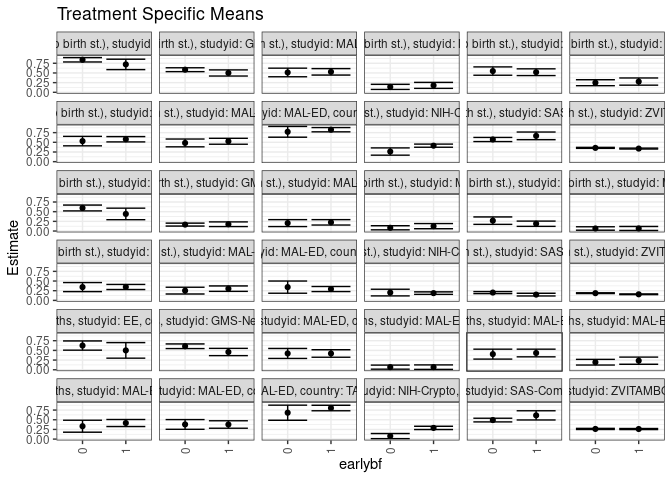

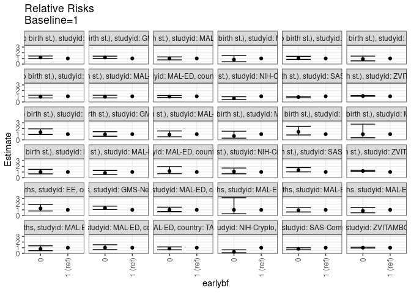

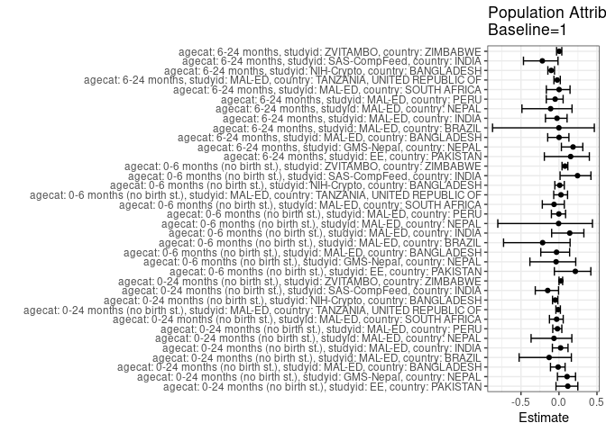

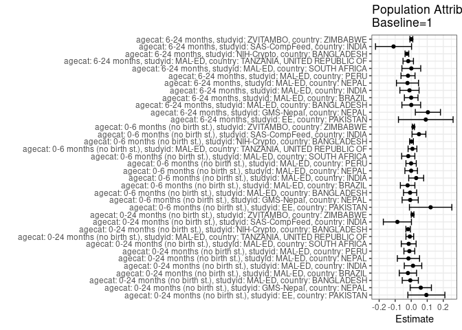

## Results Table

### Parameter: TSM

| agecat | studyid | country | intervention_level | baseline_level | estimate | ci_lower | ci_upper |
| --- | --- | --- | --- | --- | --- | --- | --- |
| 0-24 months (no birth st.) | EE | PAKISTAN | 1 | NA | 0.7209302 | 0.5865382 | 0.8553223 |
| 0-24 months (no birth st.) | EE | PAKISTAN | 0 | NA | 0.8404908 | 0.7841439 | 0.8968377 |
| 0-24 months (no birth st.) | GMS-Nepal | NEPAL | 1 | NA | 0.5000000 | 0.4209558 | 0.5790442 |
| 0-24 months (no birth st.) | GMS-Nepal | NEPAL | 0 | NA | 0.5844504 | 0.5343903 | 0.6345105 |
| 0-24 months (no birth st.) | MAL-ED | BANGLADESH | 1 | NA | 0.5289855 | 0.4455107 | 0.6124603 |
| 0-24 months (no birth st.) | MAL-ED | BANGLADESH | 0 | NA | 0.5128205 | 0.4016382 | 0.6240028 |
| 0-24 months (no birth st.) | MAL-ED | BRAZIL | 1 | NA | 0.1789474 | 0.1016772 | 0.2562176 |
| 0-24 months (no birth st.) | MAL-ED | BRAZIL | 0 | NA | 0.1401869 | 0.0742407 | 0.2061331 |
| 0-24 months (no birth st.) | MAL-ED | INDIA | 1 | NA | 0.5196850 | 0.4325845 | 0.6067856 |
| 0-24 months (no birth st.) | MAL-ED | INDIA | 0 | NA | 0.5487805 | 0.4408172 | 0.6567437 |
| 0-24 months (no birth st.) | MAL-ED | NEPAL | 1 | NA | 0.2777778 | 0.1850217 | 0.3705339 |
| 0-24 months (no birth st.) | MAL-ED | NEPAL | 0 | NA | 0.2479339 | 0.1708111 | 0.3250567 |
| 0-24 months (no birth st.) | MAL-ED | PERU | 1 | NA | 0.5792079 | 0.5109990 | 0.6474169 |
| 0-24 months (no birth st.) | MAL-ED | PERU | 0 | NA | 0.5312500 | 0.4087613 | 0.6537387 |
| 0-24 months (no birth st.) | MAL-ED | SOUTH AFRICA | 1 | NA | 0.5272727 | 0.4509479 | 0.6035976 |
| 0-24 months (no birth st.) | MAL-ED | SOUTH AFRICA | 0 | NA | 0.4842105 | 0.3835228 | 0.5848982 |
| 0-24 months (no birth st.) | MAL-ED | TANZANIA, UNITED REPUBLIC OF | 1 | NA | 0.8260870 | 0.7711946 | 0.8809793 |
| 0-24 months (no birth st.) | MAL-ED | TANZANIA, UNITED REPUBLIC OF | 0 | NA | 0.7714286 | 0.6319952 | 0.9108619 |
| 0-24 months (no birth st.) | NIH-Crypto | BANGLADESH | 1 | NA | 0.4130053 | 0.3725179 | 0.4534927 |
| 0-24 months (no birth st.) | NIH-Crypto | BANGLADESH | 0 | NA | 0.2619048 | 0.1678092 | 0.3560003 |
| 0-24 months (no birth st.) | SAS-CompFeed | INDIA | 1 | NA | 0.6666667 | 0.5681713 | 0.7651620 |
| 0-24 months (no birth st.) | SAS-CompFeed | INDIA | 0 | NA | 0.5727459 | 0.5190227 | 0.6264691 |
| 0-24 months (no birth st.) | ZVITAMBO | ZIMBABWE | 1 | NA | 0.3380187 | 0.3260250 | 0.3500125 |
| 0-24 months (no birth st.) | ZVITAMBO | ZIMBABWE | 0 | NA | 0.3562846 | 0.3433210 | 0.3692481 |
| 0-6 months (no birth st.) | EE | PAKISTAN | 1 | NA | 0.4418605 | 0.2930668 | 0.5906542 |
| 0-6 months (no birth st.) | EE | PAKISTAN | 0 | NA | 0.5950920 | 0.5195513 | 0.6706328 |
| 0-6 months (no birth st.) | GMS-Nepal | NEPAL | 1 | NA | 0.1753247 | 0.1152124 | 0.2354370 |
| 0-6 months (no birth st.) | GMS-Nepal | NEPAL | 0 | NA | 0.1662198 | 0.1284040 | 0.2040356 |
| 0-6 months (no birth st.) | MAL-ED | BANGLADESH | 1 | NA | 0.2246377 | 0.1548450 | 0.2944304 |
| 0-6 months (no birth st.) | MAL-ED | BANGLADESH | 0 | NA | 0.2051282 | 0.1153089 | 0.2949475 |
| 0-6 months (no birth st.) | MAL-ED | BRAZIL | 1 | NA | 0.1263158 | 0.0593474 | 0.1932842 |
| 0-6 months (no birth st.) | MAL-ED | BRAZIL | 0 | NA | 0.0841121 | 0.0313911 | 0.1368332 |
| 0-6 months (no birth st.) | MAL-ED | INDIA | 1 | NA | 0.1889764 | 0.1207255 | 0.2572273 |
| 0-6 months (no birth st.) | MAL-ED | INDIA | 0 | NA | 0.2682927 | 0.1721634 | 0.3644220 |
| 0-6 months (no birth st.) | MAL-ED | NEPAL | 1 | NA | 0.0666667 | 0.0150094 | 0.1183239 |
| 0-6 months (no birth st.) | MAL-ED | NEPAL | 0 | NA | 0.0661157 | 0.0217359 | 0.1104956 |
| 0-6 months (no birth st.) | MAL-ED | PERU | 1 | NA | 0.3465347 | 0.2807878 | 0.4122815 |
| 0-6 months (no birth st.) | MAL-ED | PERU | 0 | NA | 0.3437500 | 0.2271679 | 0.4603321 |
| 0-6 months (no birth st.) | MAL-ED | SOUTH AFRICA | 1 | NA | 0.3030303 | 0.2327728 | 0.3732878 |
| 0-6 months (no birth st.) | MAL-ED | SOUTH AFRICA | 0 | NA | 0.2526316 | 0.1650860 | 0.3401772 |
| 0-6 months (no birth st.) | MAL-ED | TANZANIA, UNITED REPUBLIC OF | 1 | NA | 0.2934783 | 0.2275330 | 0.3594235 |
| 0-6 months (no birth st.) | MAL-ED | TANZANIA, UNITED REPUBLIC OF | 0 | NA | 0.3428571 | 0.1852433 | 0.5004710 |
| 0-6 months (no birth st.) | NIH-Crypto | BANGLADESH | 1 | NA | 0.1880492 | 0.1559181 | 0.2201803 |
| 0-6 months (no birth st.) | NIH-Crypto | BANGLADESH | 0 | NA | 0.2023810 | 0.1163957 | 0.2883662 |
| 0-6 months (no birth st.) | SAS-CompFeed | INDIA | 1 | NA | 0.1494253 | 0.1150118 | 0.1838387 |
| 0-6 months (no birth st.) | SAS-CompFeed | INDIA | 0 | NA | 0.2020513 | 0.1758054 | 0.2282972 |
| 0-6 months (no birth st.) | ZVITAMBO | ZIMBABWE | 1 | NA | 0.1575423 | 0.1483029 | 0.1667817 |
| 0-6 months (no birth st.) | ZVITAMBO | ZIMBABWE | 0 | NA | 0.1865572 | 0.1760061 | 0.1971082 |
| 6-24 months | EE | PAKISTAN | 1 | NA | 0.5000000 | 0.2988157 | 0.7011843 |
| 6-24 months | EE | PAKISTAN | 0 | NA | 0.6250000 | 0.5057124 | 0.7442876 |
| 6-24 months | GMS-Nepal | NEPAL | 1 | NA | 0.4587156 | 0.3650428 | 0.5523884 |
| 6-24 months | GMS-Nepal | NEPAL | 0 | NA | 0.6070039 | 0.5472088 | 0.6667990 |
| 6-24 months | MAL-ED | BANGLADESH | 1 | NA | 0.4200000 | 0.3229548 | 0.5170452 |
| 6-24 months | MAL-ED | BANGLADESH | 0 | NA | 0.4210526 | 0.2924689 | 0.5496363 |
| 6-24 months | MAL-ED | BRAZIL | 1 | NA | 0.0675676 | 0.0102027 | 0.1249325 |
| 6-24 months | MAL-ED | BRAZIL | 0 | NA | 0.0674157 | 0.0151624 | 0.1196691 |
| 6-24 months | MAL-ED | INDIA | 1 | NA | 0.4329897 | 0.3340635 | 0.5319158 |
| 6-24 months | MAL-ED | INDIA | 0 | NA | 0.4035088 | 0.2757314 | 0.5312861 |
| 6-24 months | MAL-ED | NEPAL | 1 | NA | 0.2345679 | 0.1420522 | 0.3270836 |
| 6-24 months | MAL-ED | NEPAL | 0 | NA | 0.1946903 | 0.1214947 | 0.2678858 |
| 6-24 months | MAL-ED | PERU | 1 | NA | 0.4159292 | 0.3247463 | 0.5071121 |
| 6-24 months | MAL-ED | PERU | 0 | NA | 0.3333333 | 0.1788247 | 0.4878420 |
| 6-24 months | MAL-ED | SOUTH AFRICA | 1 | NA | 0.3775510 | 0.2812632 | 0.4738388 |
| 6-24 months | MAL-ED | SOUTH AFRICA | 0 | NA | 0.3793103 | 0.2540351 | 0.5045856 |
| 6-24 months | MAL-ED | TANZANIA, UNITED REPUBLIC OF | 1 | NA | 0.8032787 | 0.7324939 | 0.8740635 |
| 6-24 months | MAL-ED | TANZANIA, UNITED REPUBLIC OF | 0 | NA | 0.6818182 | 0.4865093 | 0.8771270 |
| 6-24 months | NIH-Crypto | BANGLADESH | 1 | NA | 0.2895928 | 0.2472661 | 0.3319194 |
| 6-24 months | NIH-Crypto | BANGLADESH | 0 | NA | 0.0781250 | 0.0123109 | 0.1439391 |
| 6-24 months | SAS-CompFeed | INDIA | 1 | NA | 0.6133333 | 0.4946575 | 0.7320092 |
| 6-24 months | SAS-CompFeed | INDIA | 0 | NA | 0.4918699 | 0.4444057 | 0.5393342 |
| 6-24 months | ZVITAMBO | ZIMBABWE | 1 | NA | 0.2607332 | 0.2473685 | 0.2740980 |
| 6-24 months | ZVITAMBO | ZIMBABWE | 0 | NA | 0.2626945 | 0.2479156 | 0.2774733 |

### Parameter: E(Y)

| agecat | studyid | country | intervention_level | baseline_level | estimate | ci_lower | ci_upper |
| --- | --- | --- | --- | --- | --- | --- | --- |
| 0-24 months (no birth st.) | EE | PAKISTAN | NA | NA | 0.8155340 | 0.7624394 | 0.8686286 |
| 0-24 months (no birth st.) | GMS-Nepal | NEPAL | NA | NA | 0.5597723 | 0.5173495 | 0.6021951 |
| 0-24 months (no birth st.) | MAL-ED | BANGLADESH | NA | NA | 0.5231481 | 0.4563856 | 0.5899107 |
| 0-24 months (no birth st.) | MAL-ED | BRAZIL | NA | NA | 0.1584158 | 0.1079383 | 0.2088934 |
| 0-24 months (no birth st.) | MAL-ED | INDIA | NA | NA | 0.5311005 | 0.4632825 | 0.5989184 |
| 0-24 months (no birth st.) | MAL-ED | NEPAL | NA | NA | 0.2606635 | 0.2012891 | 0.3200380 |
| 0-24 months (no birth st.) | MAL-ED | PERU | NA | NA | 0.5676692 | 0.5080232 | 0.6273151 |
| 0-24 months (no birth st.) | MAL-ED | SOUTH AFRICA | NA | NA | 0.5115385 | 0.4506616 | 0.5724154 |
| 0-24 months (no birth st.) | MAL-ED | TANZANIA, UNITED REPUBLIC OF | NA | NA | 0.8173516 | 0.7660617 | 0.8686415 |
| 0-24 months (no birth st.) | NIH-Crypto | BANGLADESH | NA | NA | 0.3935681 | 0.3560687 | 0.4310676 |
| 0-24 months (no birth st.) | SAS-CompFeed | INDIA | NA | NA | 0.5804327 | 0.5278252 | 0.6330403 |
| 0-24 months (no birth st.) | ZVITAMBO | ZIMBABWE | NA | NA | 0.3465550 | 0.3377489 | 0.3553610 |
| 0-6 months (no birth st.) | EE | PAKISTAN | NA | NA | 0.5631068 | 0.4952092 | 0.6310044 |
| 0-6 months (no birth st.) | GMS-Nepal | NEPAL | NA | NA | 0.1688805 | 0.1368637 | 0.2008972 |
| 0-6 months (no birth st.) | MAL-ED | BANGLADESH | NA | NA | 0.2175926 | 0.1624398 | 0.2727454 |
| 0-6 months (no birth st.) | MAL-ED | BRAZIL | NA | NA | 0.1039604 | 0.0617667 | 0.1461541 |
| 0-6 months (no birth st.) | MAL-ED | INDIA | NA | NA | 0.2200957 | 0.1637912 | 0.2764002 |
| 0-6 months (no birth st.) | MAL-ED | NEPAL | NA | NA | 0.0663507 | 0.0326877 | 0.1000137 |
| 0-6 months (no birth st.) | MAL-ED | PERU | NA | NA | 0.3458647 | 0.2885967 | 0.4031327 |
| 0-6 months (no birth st.) | MAL-ED | SOUTH AFRICA | NA | NA | 0.2846154 | 0.2296617 | 0.3395691 |
| 0-6 months (no birth st.) | MAL-ED | TANZANIA, UNITED REPUBLIC OF | NA | NA | 0.3013699 | 0.2404592 | 0.3622805 |
| 0-6 months (no birth st.) | NIH-Crypto | BANGLADESH | NA | NA | 0.1898928 | 0.1597870 | 0.2199986 |
| 0-6 months (no birth st.) | SAS-CompFeed | INDIA | NA | NA | 0.1977401 | 0.1736271 | 0.2218531 |
| 0-6 months (no birth st.) | ZVITAMBO | ZIMBABWE | NA | NA | 0.1710972 | 0.1641255 | 0.1780689 |
| 6-24 months | EE | PAKISTAN | NA | NA | 0.5909091 | 0.4875952 | 0.6942230 |
| 6-24 months | GMS-Nepal | NEPAL | NA | NA | 0.5628415 | 0.5119537 | 0.6137294 |
| 6-24 months | MAL-ED | BANGLADESH | NA | NA | 0.4203822 | 0.3429219 | 0.4978424 |
| 6-24 months | MAL-ED | BRAZIL | NA | NA | 0.0674847 | 0.0288550 | 0.1061143 |
| 6-24 months | MAL-ED | INDIA | NA | NA | 0.4220779 | 0.3438191 | 0.5003367 |
| 6-24 months | MAL-ED | NEPAL | NA | NA | 0.2113402 | 0.1537425 | 0.2689379 |
| 6-24 months | MAL-ED | PERU | NA | NA | 0.3959732 | 0.3171819 | 0.4747644 |
| 6-24 months | MAL-ED | SOUTH AFRICA | NA | NA | 0.3782051 | 0.3018621 | 0.4545482 |
| 6-24 months | MAL-ED | TANZANIA, UNITED REPUBLIC OF | NA | NA | 0.7847222 | 0.7173567 | 0.8520877 |
| 6-24 months | NIH-Crypto | BANGLADESH | NA | NA | 0.2628458 | 0.2244546 | 0.3012371 |
| 6-24 months | SAS-CompFeed | INDIA | NA | NA | 0.5030750 | 0.4588491 | 0.5473009 |
| 6-24 months | ZVITAMBO | ZIMBABWE | NA | NA | 0.2616179 | 0.2517052 | 0.2715306 |

### Parameter: RR

| agecat | studyid | country | intervention_level | baseline_level | estimate | ci_lower | ci_upper |
| --- | --- | --- | --- | --- | --- | --- | --- |
| 0-24 months (no birth st.) | EE | PAKISTAN | 1 | 1 | 1.0000000 | 1.0000000 | 1.0000000 |
| 0-24 months (no birth st.) | EE | PAKISTAN | 0 | 1 | 1.1658421 | 0.9563229 | 1.4212644 |
| 0-24 months (no birth st.) | GMS-Nepal | NEPAL | 1 | 1 | 1.0000000 | 1.0000000 | 1.0000000 |
| 0-24 months (no birth st.) | GMS-Nepal | NEPAL | 0 | 1 | 1.1689008 | 0.9765422 | 1.3991500 |
| 0-24 months (no birth st.) | MAL-ED | BANGLADESH | 1 | 1 | 1.0000000 | 1.0000000 | 1.0000000 |
| 0-24 months (no birth st.) | MAL-ED | BANGLADESH | 0 | 1 | 0.9694415 | 0.7414200 | 1.2675904 |
| 0-24 months (no birth st.) | MAL-ED | BRAZIL | 1 | 1 | 1.0000000 | 1.0000000 | 1.0000000 |
| 0-24 months (no birth st.) | MAL-ED | BRAZIL | 0 | 1 | 0.7833975 | 0.4136790 | 1.4835456 |
| 0-24 months (no birth st.) | MAL-ED | INDIA | 1 | 1 | 1.0000000 | 1.0000000 | 1.0000000 |
| 0-24 months (no birth st.) | MAL-ED | INDIA | 0 | 1 | 1.0559867 | 0.8154862 | 1.3674147 |
| 0-24 months (no birth st.) | MAL-ED | NEPAL | 1 | 1 | 1.0000000 | 1.0000000 | 1.0000000 |
| 0-24 months (no birth st.) | MAL-ED | NEPAL | 0 | 1 | 0.8925620 | 0.5655151 | 1.4087456 |
| 0-24 months (no birth st.) | MAL-ED | PERU | 1 | 1 | 1.0000000 | 1.0000000 | 1.0000000 |
| 0-24 months (no birth st.) | MAL-ED | PERU | 0 | 1 | 0.9172009 | 0.7079876 | 1.1882374 |
| 0-24 months (no birth st.) | MAL-ED | SOUTH AFRICA | 1 | 1 | 1.0000000 | 1.0000000 | 1.0000000 |
| 0-24 months (no birth st.) | MAL-ED | SOUTH AFRICA | 0 | 1 | 0.9183303 | 0.7127941 | 1.1831335 |
| 0-24 months (no birth st.) | MAL-ED | TANZANIA, UNITED REPUBLIC OF | 1 | 1 | 1.0000000 | 1.0000000 | 1.0000000 |
| 0-24 months (no birth st.) | MAL-ED | TANZANIA, UNITED REPUBLIC OF | 0 | 1 | 0.9338346 | 0.7702576 | 1.1321499 |
| 0-24 months (no birth st.) | NIH-Crypto | BANGLADESH | 1 | 1 | 1.0000000 | 1.0000000 | 1.0000000 |
| 0-24 months (no birth st.) | NIH-Crypto | BANGLADESH | 0 | 1 | 0.6341439 | 0.4369713 | 0.9202856 |
| 0-24 months (no birth st.) | SAS-CompFeed | INDIA | 1 | 1 | 1.0000000 | 1.0000000 | 1.0000000 |
| 0-24 months (no birth st.) | SAS-CompFeed | INDIA | 0 | 1 | 0.8591189 | 0.7401777 | 0.9971730 |
| 0-24 months (no birth st.) | ZVITAMBO | ZIMBABWE | 1 | 1 | 1.0000000 | 1.0000000 | 1.0000000 |
| 0-24 months (no birth st.) | ZVITAMBO | ZIMBABWE | 0 | 1 | 1.0540379 | 1.0018078 | 1.1089911 |
| 0-6 months (no birth st.) | EE | PAKISTAN | 1 | 1 | 1.0000000 | 1.0000000 | 1.0000000 |
| 0-6 months (no birth st.) | EE | PAKISTAN | 0 | 1 | 1.3467872 | 0.9397391 | 1.9301482 |
| 0-6 months (no birth st.) | GMS-Nepal | NEPAL | 1 | 1 | 1.0000000 | 1.0000000 | 1.0000000 |
| 0-6 months (no birth st.) | GMS-Nepal | NEPAL | 0 | 1 | 0.9480687 | 0.6282575 | 1.4306781 |
| 0-6 months (no birth st.) | MAL-ED | BANGLADESH | 1 | 1 | 1.0000000 | 1.0000000 | 1.0000000 |
| 0-6 months (no birth st.) | MAL-ED | BANGLADESH | 0 | 1 | 0.9131514 | 0.5337915 | 1.5621181 |
| 0-6 months (no birth st.) | MAL-ED | BRAZIL | 1 | 1 | 1.0000000 | 1.0000000 | 1.0000000 |
| 0-6 months (no birth st.) | MAL-ED | BRAZIL | 0 | 1 | 0.6658879 | 0.2930014 | 1.5133259 |
| 0-6 months (no birth st.) | MAL-ED | INDIA | 1 | 1 | 1.0000000 | 1.0000000 | 1.0000000 |
| 0-6 months (no birth st.) | MAL-ED | INDIA | 0 | 1 | 1.4197154 | 0.8536079 | 2.3612620 |
| 0-6 months (no birth st.) | MAL-ED | NEPAL | 1 | 1 | 1.0000000 | 1.0000000 | 1.0000000 |
| 0-6 months (no birth st.) | MAL-ED | NEPAL | 0 | 1 | 0.9917355 | 0.3557703 | 2.7645348 |
| 0-6 months (no birth st.) | MAL-ED | PERU | 1 | 1 | 1.0000000 | 1.0000000 | 1.0000000 |
| 0-6 months (no birth st.) | MAL-ED | PERU | 0 | 1 | 0.9919643 | 0.6725506 | 1.4630768 |
| 0-6 months (no birth st.) | MAL-ED | SOUTH AFRICA | 1 | 1 | 1.0000000 | 1.0000000 | 1.0000000 |
| 0-6 months (no birth st.) | MAL-ED | SOUTH AFRICA | 0 | 1 | 0.8336842 | 0.5494472 | 1.2649611 |
| 0-6 months (no birth st.) | MAL-ED | TANZANIA, UNITED REPUBLIC OF | 1 | 1 | 1.0000000 | 1.0000000 | 1.0000000 |
| 0-6 months (no birth st.) | MAL-ED | TANZANIA, UNITED REPUBLIC OF | 0 | 1 | 1.1682540 | 0.7003501 | 1.9487644 |
| 0-6 months (no birth st.) | NIH-Crypto | BANGLADESH | 1 | 1 | 1.0000000 | 1.0000000 | 1.0000000 |
| 0-6 months (no birth st.) | NIH-Crypto | BANGLADESH | 0 | 1 | 1.0762127 | 0.6807973 | 1.7012902 |
| 0-6 months (no birth st.) | SAS-CompFeed | INDIA | 1 | 1 | 1.0000000 | 1.0000000 | 1.0000000 |
| 0-6 months (no birth st.) | SAS-CompFeed | INDIA | 0 | 1 | 1.3521893 | 1.0252467 | 1.7833913 |
| 0-6 months (no birth st.) | ZVITAMBO | ZIMBABWE | 1 | 1 | 1.0000000 | 1.0000000 | 1.0000000 |
| 0-6 months (no birth st.) | ZVITAMBO | ZIMBABWE | 0 | 1 | 1.1841723 | 1.0915178 | 1.2846917 |
| 6-24 months | EE | PAKISTAN | 1 | 1 | 1.0000000 | 1.0000000 | 1.0000000 |
| 6-24 months | EE | PAKISTAN | 0 | 1 | 1.2500000 | 0.8007576 | 1.9512771 |
| 6-24 months | GMS-Nepal | NEPAL | 1 | 1 | 1.0000000 | 1.0000000 | 1.0000000 |
| 6-24 months | GMS-Nepal | NEPAL | 0 | 1 | 1.3232685 | 1.0548300 | 1.6600206 |
| 6-24 months | MAL-ED | BANGLADESH | 1 | 1 | 1.0000000 | 1.0000000 | 1.0000000 |
| 6-24 months | MAL-ED | BANGLADESH | 0 | 1 | 1.0025063 | 0.6835569 | 1.4702782 |
| 6-24 months | MAL-ED | BRAZIL | 1 | 1 | 1.0000000 | 1.0000000 | 1.0000000 |
| 6-24 months | MAL-ED | BRAZIL | 0 | 1 | 0.9977528 | 0.3160532 | 3.1498199 |
| 6-24 months | MAL-ED | INDIA | 1 | 1 | 1.0000000 | 1.0000000 | 1.0000000 |
| 6-24 months | MAL-ED | INDIA | 0 | 1 | 0.9319131 | 0.6306537 | 1.3770822 |
| 6-24 months | MAL-ED | NEPAL | 1 | 1 | 1.0000000 | 1.0000000 | 1.0000000 |
| 6-24 months | MAL-ED | NEPAL | 0 | 1 | 0.8299953 | 0.4813196 | 1.4312575 |
| 6-24 months | MAL-ED | PERU | 1 | 1 | 1.0000000 | 1.0000000 | 1.0000000 |
| 6-24 months | MAL-ED | PERU | 0 | 1 | 0.8014184 | 0.4799246 | 1.3382759 |
| 6-24 months | MAL-ED | SOUTH AFRICA | 1 | 1 | 1.0000000 | 1.0000000 | 1.0000000 |
| 6-24 months | MAL-ED | SOUTH AFRICA | 0 | 1 | 1.0046598 | 0.6619081 | 1.5248965 |
| 6-24 months | MAL-ED | TANZANIA, UNITED REPUBLIC OF | 1 | 1 | 1.0000000 | 1.0000000 | 1.0000000 |
| 6-24 months | MAL-ED | TANZANIA, UNITED REPUBLIC OF | 0 | 1 | 0.8487941 | 0.6289904 | 1.1454091 |
| 6-24 months | NIH-Crypto | BANGLADESH | 1 | 1 | 1.0000000 | 1.0000000 | 1.0000000 |
| 6-24 months | NIH-Crypto | BANGLADESH | 0 | 1 | 0.2697754 | 0.1147303 | 0.6343463 |
| 6-24 months | SAS-CompFeed | INDIA | 1 | 1 | 1.0000000 | 1.0000000 | 1.0000000 |
| 6-24 months | SAS-CompFeed | INDIA | 0 | 1 | 0.8019618 | 0.6483931 | 0.9919026 |
| 6-24 months | ZVITAMBO | ZIMBABWE | 1 | 1 | 1.0000000 | 1.0000000 | 1.0000000 |
| 6-24 months | ZVITAMBO | ZIMBABWE | 0 | 1 | 1.0075219 | 0.9336867 | 1.0871960 |

### Parameter: PAR

| agecat | studyid | country | intervention_level | baseline_level | estimate | ci_lower | ci_upper |
| --- | --- | --- | --- | --- | --- | --- | --- |
| 0-24 months (no birth st.) | EE | PAKISTAN | 1 | NA | 0.0946037 | -0.0208958 | 0.2101033 |
| 0-24 months (no birth st.) | GMS-Nepal | NEPAL | 1 | NA | 0.0597723 | -0.0065309 | 0.1260755 |
| 0-24 months (no birth st.) | MAL-ED | BANGLADESH | 1 | NA | -0.0058374 | -0.0560536 | 0.0443789 |
| 0-24 months (no birth st.) | MAL-ED | BRAZIL | 1 | NA | -0.0205315 | -0.0744080 | 0.0333450 |
| 0-24 months (no birth st.) | MAL-ED | INDIA | 1 | NA | 0.0114154 | -0.0430439 | 0.0658747 |
| 0-24 months (no birth st.) | MAL-ED | NEPAL | 1 | NA | -0.0171143 | -0.0863196 | 0.0520910 |
| 0-24 months (no birth st.) | MAL-ED | PERU | 1 | NA | -0.0115387 | -0.0453612 | 0.0222837 |
| 0-24 months (no birth st.) | MAL-ED | SOUTH AFRICA | 1 | NA | -0.0157343 | -0.0619684 | 0.0304999 |
| 0-24 months (no birth st.) | MAL-ED | TANZANIA, UNITED REPUBLIC OF | 1 | NA | -0.0087354 | -0.0328310 | 0.0153603 |
| 0-24 months (no birth st.) | NIH-Crypto | BANGLADESH | 1 | NA | -0.0194371 | -0.0331745 | -0.0056998 |
| 0-24 months (no birth st.) | SAS-CompFeed | INDIA | 1 | NA | -0.0862339 | -0.1739786 | 0.0015107 |
| 0-24 months (no birth st.) | ZVITAMBO | ZIMBABWE | 1 | NA | 0.0085362 | 0.0002810 | 0.0167914 |
| 0-6 months (no birth st.) | EE | PAKISTAN | 1 | NA | 0.1212463 | -0.0110674 | 0.2535600 |
| 0-6 months (no birth st.) | GMS-Nepal | NEPAL | 1 | NA | -0.0064442 | -0.0567104 | 0.0438220 |
| 0-6 months (no birth st.) | MAL-ED | BANGLADESH | 1 | NA | -0.0070451 | -0.0481397 | 0.0340495 |
| 0-6 months (no birth st.) | MAL-ED | BRAZIL | 1 | NA | -0.0223554 | -0.0675962 | 0.0228854 |
| 0-6 months (no birth st.) | MAL-ED | INDIA | 1 | NA | 0.0311193 | -0.0154343 | 0.0776729 |
| 0-6 months (no birth st.) | MAL-ED | NEPAL | 1 | NA | -0.0003160 | -0.0393704 | 0.0387385 |
| 0-6 months (no birth st.) | MAL-ED | PERU | 1 | NA | -0.0006700 | -0.0328732 | 0.0315332 |
| 0-6 months (no birth st.) | MAL-ED | SOUTH AFRICA | 1 | NA | -0.0184149 | -0.0595362 | 0.0227063 |
| 0-6 months (no birth st.) | MAL-ED | TANZANIA, UNITED REPUBLIC OF | 1 | NA | 0.0078916 | -0.0195192 | 0.0353024 |
| 0-6 months (no birth st.) | NIH-Crypto | BANGLADESH | 1 | NA | 0.0018436 | -0.0099701 | 0.0136573 |
| 0-6 months (no birth st.) | SAS-CompFeed | INDIA | 1 | NA | 0.0483148 | 0.0053458 | 0.0912839 |
| 0-6 months (no birth st.) | ZVITAMBO | ZIMBABWE | 1 | NA | 0.0135550 | 0.0069976 | 0.0201124 |
| 6-24 months | EE | PAKISTAN | 1 | NA | 0.0909091 | -0.0795947 | 0.2614129 |
| 6-24 months | GMS-Nepal | NEPAL | 1 | NA | 0.1041259 | 0.0257820 | 0.1824699 |
| 6-24 months | MAL-ED | BANGLADESH | 1 | NA | 0.0003822 | -0.0581046 | 0.0588689 |
| 6-24 months | MAL-ED | BRAZIL | 1 | NA | -0.0000829 | -0.0424513 | 0.0422855 |
| 6-24 months | MAL-ED | INDIA | 1 | NA | -0.0109118 | -0.0707660 | 0.0489424 |
| 6-24 months | MAL-ED | NEPAL | 1 | NA | -0.0232277 | -0.0919977 | 0.0455423 |
| 6-24 months | MAL-ED | PERU | 1 | NA | -0.0199560 | -0.0636756 | 0.0237635 |
| 6-24 months | MAL-ED | SOUTH AFRICA | 1 | NA | 0.0006541 | -0.0580911 | 0.0593993 |
| 6-24 months | MAL-ED | TANZANIA, UNITED REPUBLIC OF | 1 | NA | -0.0185565 | -0.0510927 | 0.0139797 |
| 6-24 months | NIH-Crypto | BANGLADESH | 1 | NA | -0.0267469 | -0.0383890 | -0.0151048 |
| 6-24 months | SAS-CompFeed | INDIA | 1 | NA | -0.1102583 | -0.2228632 | 0.0023466 |
| 6-24 months | ZVITAMBO | ZIMBABWE | 1 | NA | 0.0008847 | -0.0081034 | 0.0098727 |

### Parameter: PAF

| agecat | studyid | country | intervention_level | baseline_level | estimate | ci_lower | ci_upper |
| --- | --- | --- | --- | --- | --- | --- | --- |
| 0-24 months (no birth st.) | EE | PAKISTAN | 1 | NA | 0.1160022 | -0.0392024 | 0.2480271 |
| 0-24 months (no birth st.) | GMS-Nepal | NEPAL | 1 | NA | 0.1067797 | -0.0202802 | 0.2180162 |
| 0-24 months (no birth st.) | MAL-ED | BANGLADESH | 1 | NA | -0.0111581 | -0.1118646 | 0.0804269 |
| 0-24 months (no birth st.) | MAL-ED | BRAZIL | 1 | NA | -0.1296053 | -0.5244967 | 0.1629971 |
| 0-24 months (no birth st.) | MAL-ED | INDIA | 1 | NA | 0.0214939 | -0.0866616 | 0.1188848 |
| 0-24 months (no birth st.) | MAL-ED | NEPAL | 1 | NA | -0.0656566 | -0.3670184 | 0.1692694 |
| 0-24 months (no birth st.) | MAL-ED | PERU | 1 | NA | -0.0203265 | -0.0817498 | 0.0376091 |
| 0-24 months (no birth st.) | MAL-ED | SOUTH AFRICA | 1 | NA | -0.0307587 | -0.1253161 | 0.0558532 |
| 0-24 months (no birth st.) | MAL-ED | TANZANIA, UNITED REPUBLIC OF | 1 | NA | -0.0106874 | -0.0406648 | 0.0184265 |
| 0-24 months (no birth st.) | NIH-Crypto | BANGLADESH | 1 | NA | -0.0493869 | -0.0849970 | -0.0149456 |
| 0-24 months (no birth st.) | SAS-CompFeed | INDIA | 1 | NA | -0.1485683 | -0.3120868 | -0.0054283 |
| 0-24 months (no birth st.) | ZVITAMBO | ZIMBABWE | 1 | NA | 0.0246316 | 0.0005174 | 0.0481641 |
| 0-6 months (no birth st.) | EE | PAKISTAN | 1 | NA | 0.2153168 | -0.0606005 | 0.4194536 |
| 0-6 months (no birth st.) | GMS-Nepal | NEPAL | 1 | NA | -0.0381585 | -0.3827896 | 0.2205806 |
| 0-6 months (no birth st.) | MAL-ED | BANGLADESH | 1 | NA | -0.0323774 | -0.2395249 | 0.1401519 |
| 0-6 months (no birth st.) | MAL-ED | BRAZIL | 1 | NA | -0.2150376 | -0.7293081 | 0.1462965 |
| 0-6 months (no birth st.) | MAL-ED | INDIA | 1 | NA | 0.1413899 | -0.0964111 | 0.3276142 |
| 0-6 months (no birth st.) | MAL-ED | NEPAL | 1 | NA | -0.0047619 | -0.8050043 | 0.4406958 |
| 0-6 months (no birth st.) | MAL-ED | PERU | 1 | NA | -0.0019372 | -0.0995100 | 0.0869769 |
| 0-6 months (no birth st.) | MAL-ED | SOUTH AFRICA | 1 | NA | -0.0647011 | -0.2193484 | 0.0703327 |
| 0-6 months (no birth st.) | MAL-ED | TANZANIA, UNITED REPUBLIC OF | 1 | NA | 0.0261858 | -0.0691241 | 0.1129990 |
| 0-6 months (no birth st.) | NIH-Crypto | BANGLADESH | 1 | NA | 0.0097086 | -0.0544885 | 0.0699974 |
| 0-6 months (no birth st.) | SAS-CompFeed | INDIA | 1 | NA | 0.2443350 | 0.0142741 | 0.4207014 |
| 0-6 months (no birth st.) | ZVITAMBO | ZIMBABWE | 1 | NA | 0.0792237 | 0.0401772 | 0.1166818 |
| 6-24 months | EE | PAKISTAN | 1 | NA | 0.1538462 | -0.1925419 | 0.3996217 |
| 6-24 months | GMS-Nepal | NEPAL | 1 | NA | 0.1850004 | 0.0319084 | 0.3138828 |
| 6-24 months | MAL-ED | BANGLADESH | 1 | NA | 0.0009091 | -0.1483712 | 0.1307840 |
| 6-24 months | MAL-ED | BRAZIL | 1 | NA | -0.0012285 | -0.8743831 | 0.4651795 |
| 6-24 months | MAL-ED | INDIA | 1 | NA | -0.0258525 | -0.1779764 | 0.1066261 |
| 6-24 months | MAL-ED | NEPAL | 1 | NA | -0.1099067 | -0.4872812 | 0.1717149 |
| 6-24 months | MAL-ED | PERU | 1 | NA | -0.0503975 | -0.1670102 | 0.0545628 |
| 6-24 months | MAL-ED | SOUTH AFRICA | 1 | NA | 0.0017295 | -0.1663327 | 0.1455749 |
| 6-24 months | MAL-ED | TANZANIA, UNITED REPUBLIC OF | 1 | NA | -0.0236472 | -0.0662936 | 0.0172936 |
| 6-24 months | NIH-Crypto | BANGLADESH | 1 | NA | -0.1017589 | -0.1463941 | -0.0588616 |
| 6-24 months | SAS-CompFeed | INDIA | 1 | NA | -0.2191687 | -0.4671379 | -0.0131102 |
| 6-24 months | ZVITAMBO | ZIMBABWE | 1 | NA | 0.0033815 | -0.0315731 | 0.0371517 |